# explanation_1 slides

## Univariate

```
  1 -Geographical
  2 - user type histogram (countplot)
  3 - member gender histogram (countplot)
  4 - member birth year distribution
  5 - bike share
  6 - distance
  7 - duration
```

### Geographical

#### clustring

We have 3 different areas ,I've used k means to cluster these areas from lontitude and latitude

area 0 red

area 1 blue

area 2 grean

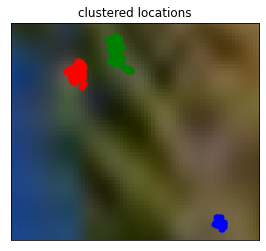

```python
X=np.zeros((329,2))
for i in range(329):
  X[i]=end_id2location[end_ids[i]]
kmeans = KMeans(n_clusters=3, random_state=0).fit(X)
id2label={}
for i in range(end_ids.shape[0]):
  id2label[end_ids[i]]=kmeans.labels_[i]
colors=[]
colors.append("red")
colors.append("blue")
colors.append("green")

m = Basemap(projection='lcc', resolution=None, lat_0=37.6 ,lon_0=-122.2,width=8E4, height=7E4 )
m.bluemarble(scale=6.5)
plt.title("clustered locations")
for i,id in enumerate(end_ids):
  long_index=0
  lat_index=1
  x, y = m(end_id2location[id][long_index], end_id2location[id][lat_index])
  plt.plot(x, y, 'ok', markersize=5,color=colors[id2label[id]])
del m  # around 7 giga and will not used again
```

### user type

we have a lot more subscribers than customers

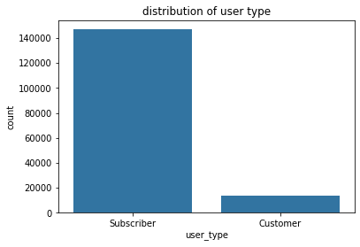

```python
sns.countplot(data=data_clean, x='user_type',color=base_color);
plt.title("distribution of user type");
```

### member gender

we have a lot males than females

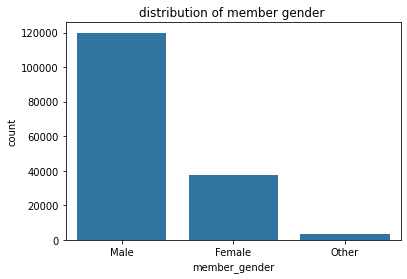

```python
sns.countplot(data=data_clean, x='member_gender',color=base_color);
plt.title("distribution of member gender ");
```

### member birthyear

the peak count of birthyears between 1985 to 1995

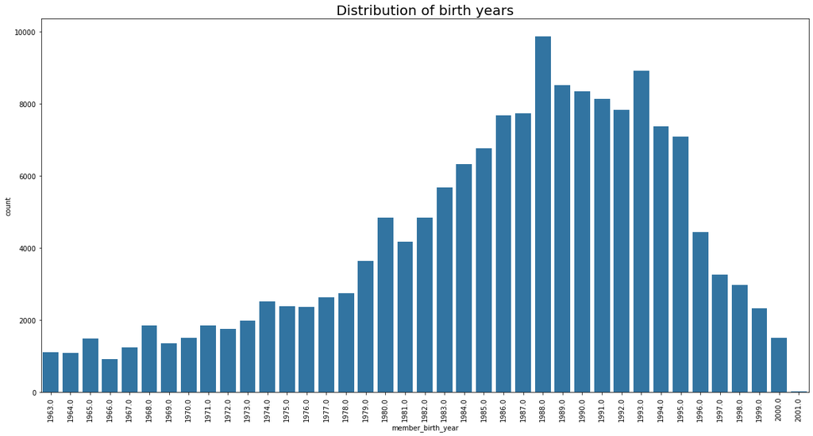

```python
plt.figure(figsize=[20,10])
sns.countplot(data=data_clean, x='member_birth_year',color=base_color);
plt.xticks(rotation=90)
plt.title("Distribution of birth years",fontsize=20);
```

### bike share

most of the cyclists don't share the bike

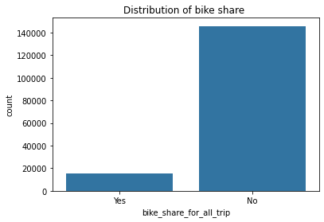

```python
sns.countplot(data=data_clean, x='bike_share_for_all_trip',color=base_color);
plt.title("Distribution of bike share ")
```

### distance

Most of the cyclist cycle for around 1

the number od cyclists starts to decline for more or less than 1 km

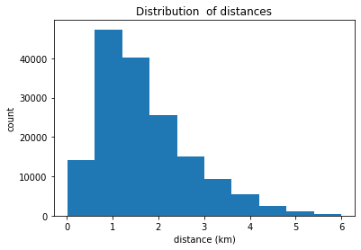

```python
plt.hist(data = data_clean, x = 'distance');
plt.title("Distribution  of distances")
plt.xlabel('distance (km)')
plt.ylabel('count')
```

### duration

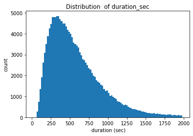

```python
bins=np.arange(20,2000,20)
plt.hist(data = data_clean, x = 'duration_sec',bins=bins);
plt.title("Distribution  of duration_sec")
plt.xlabel(' duration (sec)')
plt.ylabel('count')
```

## Bivariate

```
  1 - duration vs gender (box plot & violin plot)
  2 - member birth year vs duration (hear map)
  3 - user type vs duration (box plot & violin plot)
  4 - duration distance  (heatmap )
  5 - bike share - gender (faceting histogram )
```

### duration vs gender

the gender doesn't affect the duration but there is a little increase in the female mean duration

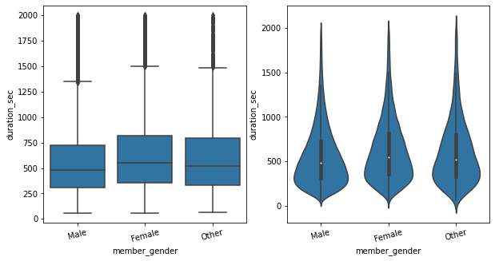

```python
plt.figure(figsize=[10,5])
plt.subplot(1,2,1)
sns.boxplot(data=data_2, x='member_gender', y='duration_sec', color=base_color)
plt.xticks(rotation=15);
plt.subplot(1,2,2)
ax1 = sns.violinplot(data=data_2, x='member_gender', y='duration_sec', color=base_color, innner='quartile')
plt.xticks(rotation=15);
# plt.ylim(ax1.get_ylim()) # set y-axis limits to be same as left plot
```

### member birth year vs duration

we have a very small number who cycle for more than 1750 sec

most of the cyclist birthdate are between 1985 and 1995 and they cycle for less than 500 secounds may be they use it for small trips

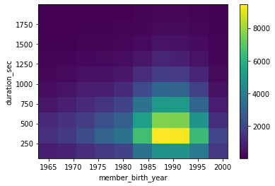

```python
plt.hist2d(data=data_2, x='member_birth_year', y='duration_sec',cmin=0.5) #I didn't notice that before but i think we need to remove some of these birthdates
# sns.boxplot()

plt.colorbar()
plt.xlabel('member_birth_year')
plt.ylabel('duration_sec');
```

### user type vs duration

customers usualy cycle for more time than subscribers

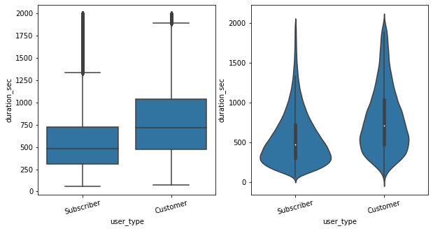

```python
base_color=sns.color_palette()[0]
plt.figure(figsize=[10,5])
plt.subplot(1,2,1)
sns.boxplot(data=data_2, x='user_type', y='duration_sec', color=base_color)
plt.xticks(rotation=15);
plt.subplot(1,2,2)
ax1 = sns.violinplot(data=data_2, x='user_type', y='duration_sec', color=base_color, innner='quartile')
plt.xticks(rotation=15);
```

### duration distance

surely more distance will need more time so there is a positive corelation

most of our cyclist doesn't cycle more than 500 sec and around 1 km

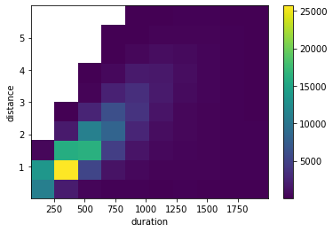

```python
plt.hist2d(data=data_2,  x = 'duration_sec', y = 'distance',cmin=0.5) #positive strong corelation
# sns.boxplot()

plt.colorbar()
plt.xlabel('duration')
plt.ylabel('distance')
```

### bike share - gender

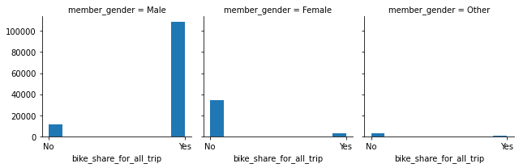

```python
g = sns.FacetGrid(data = data_2, col = 'member_gender')
g.map(plt.hist, "bike_share_for_all_trip")
```

## multivariate

area 0 the red one

area 1 the blue one

area 2 the grean one

area 0 has a lot more cyclits than the two others

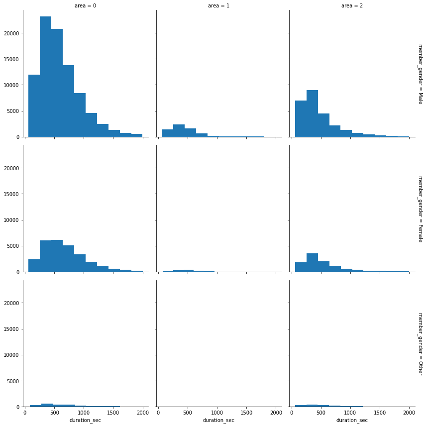

```python
g = sns.FacetGrid(data = data3, col = 'area',row='member_gender', margin_titles = True,size = 4)


g.map(plt.hist,  'duration_sec')
```